# 因素分析 (Factor Analysis)

JianKai Wang (https://sophia.ddns.net/)

2018年3月13日

因素分析是主成分分析的推廣與發展，也是降維的一種方式，可用來分析隱藏在表面現象背後的因素。因素分析是研究相關矩陣或共變異矩陣的內部依賴關係，將多個變數綜合為少數幾個因素，再現原始變數與因素間的關係。

## 原始資料

了解學生學習狀況，隨機選取 12 名學生 5 門課程期末考成績(即 x1, x2, x3, x4, x5)，試用因素分析方法進行分析。

```r
data <- data.frame(
  x1 = c(99,99,100,93,100,90,75,93,87,95,76,85),
  x2 = c(94,88,98,88,91,78,73,84,73,82,72,75),
  x3 = c(93,96,81,88,72,82,88,83,60,90,43,50),
  x4 = c(100,99,96,99,96,75,97,68,76,62,67,34),
  x5 = c(100,97,100,96,78,97,89,88,84,39,78,37)
)
data
```

```
##     x1 x2 x3  x4  x5
## 1   99 94 93 100 100
## 2   99 88 96  99  97
## 3  100 98 81  96 100
## 4   93 88 88  99  96
## 5  100 91 72  96  78
## 6   90 78 82  75  97
## 7   75 73 88  97  89
## 8   93 84 83  68  88
## 9   87 73 60  76  84
## 10  95 82 90  62  39
## 11  76 72 43  67  78
## 12  85 75 50  34  37
```

## 因素分析

### 目的

1. 找出 5 門課程的公共因素，進行解釋
2. 用迴歸方法計算樣本的因素分數，畫出第 1, 第 2 共因素的散點圖，並用此圖分析 12 名學生學習狀況。
- 因素分析

使用 **factanal** 進行分析，此方法使用最大似然估計 (Maximum likelihood estimation) 來估計參數。

```r
# the factanal prototype
# x: 資料公式
# factors: 因數個數
# data: 資料內容
# covmat: 樣本的相關矩陣或共變異矩陣
# rotation: 進行矩陣旋轉變換
# |- varimax(x, mormalize=TRUE, eps=1e-5)
# scores: 因素得分計算方式
factanal(x, factors, data = NULL, covmat=NULL, rotation="varimax", scores=c("none","rotation","regression","Bartlett"), ...)
```

```r
fa = factanal(x = ~., factors=2, data = data, scores = "regression")
fa
```

```
##
## Call:
## factanal(x = ~., factors = 2, data = data, scores = "regression")
##
## Uniquenesses:
##    x1    x2    x3    x4    x5
## 0.005 0.141 0.494 0.005 0.346
##
## Loadings:
##    Factor1 Factor2
## x1 0.992   0.104
## x2 0.854   0.360
## x3 0.497   0.509
## x4 0.284   0.956
## x5 0.132   0.798
##
##                Factor1 Factor2
## SS loadings      2.059   1.950
## Proportion Var   0.412   0.390
## Cumulative Var   0.412   0.802
##
## Test of the hypothesis that 2 factors are sufficient.
## The chi square statistic is 0.28 on 1 degree of freedom.
## The p-value is 0.598
```

其中，**SS Loadings, Proportion Var, Cumulative Var** 定義如下:

SS Loadings 為公共因素 $f_i$ 對變數 $x_1$, $x_2$, $x_3$, $x_4$, $x_5$ 的總方差貢獻，即 $g_j^2=\sum_{i=1}^{5}{a_{ij}^2}$

Proportion Var 為方差貢獻率，即 $g_j^2 / \sum_{i=1}^{5}{var(x_i)}$

Cumulative Var 為累積方差貢獻率，即 $\sum_{k=1}^{j}{g_j^2} / \sum_{i=1}^{5}{var(x_i)}$

- 結果分析

第一公共因素主要由 x1, x2 兩個係數絕對值較大的變數決定，第二公共因素主要由 x4, x5 兩個係數絕對值較大的變數決定，若畫出 12 名學生在第 1、第 2 公共因素下的散布圖，

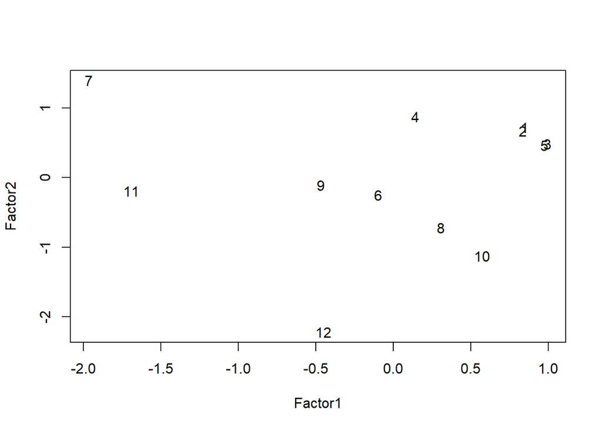

```r
plot(fa$scores, type="n")
text(fa$scores[,1], fa$scores[,2])
```

由上可以看出，學生 1, 2, 5, 3 總體表現較好。